# Analyzing Individual BGG Users

Phil Henrickson

2022-01-02

# **yourwhiteshadow’s** BoardGameGeek Collection

This notebook contains a set of analyses for the selected user’s boardgamegeek collection. The bulk of the analysis is focused on building a user-specific predictive model to predict the games that yourwhiteshadow is likely to own. This enables to ask questions like, based on the games the user currently owns, what games are a good fit for their collection? What upcoming games are they likely to purchase?

This analysis is based on data from BoardGameGeek that was last updated on **2021-12-20.**

# 1 Collection Overview

We can look at a basic description of the number of games that the user owns, has rated, has previously owned, etc.

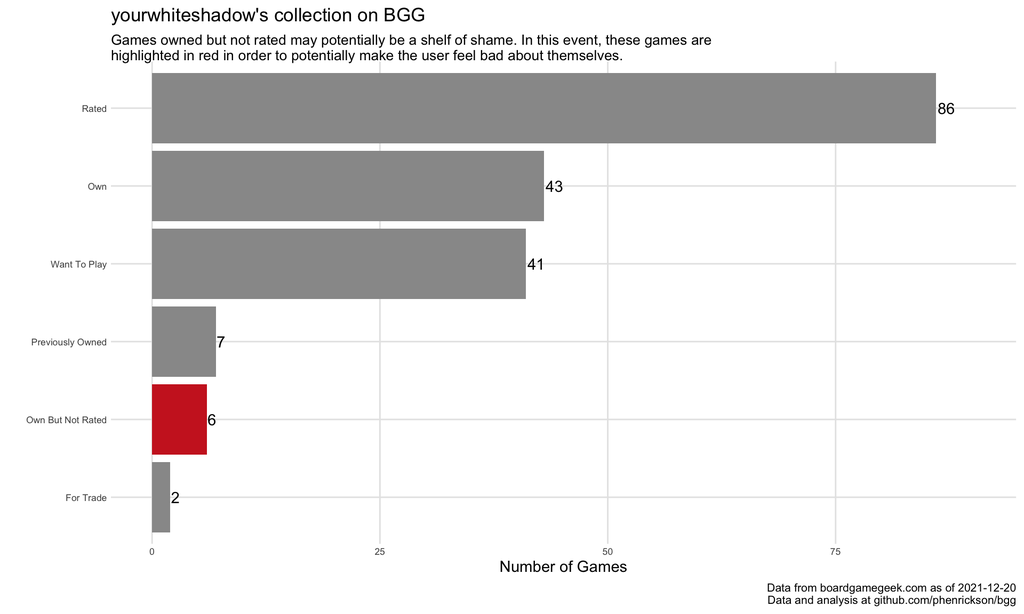

What years has the user owned/rated games from? While we can’t see when a user added or removed a game from their collection, we can look at their collection by the years in which their games were published.

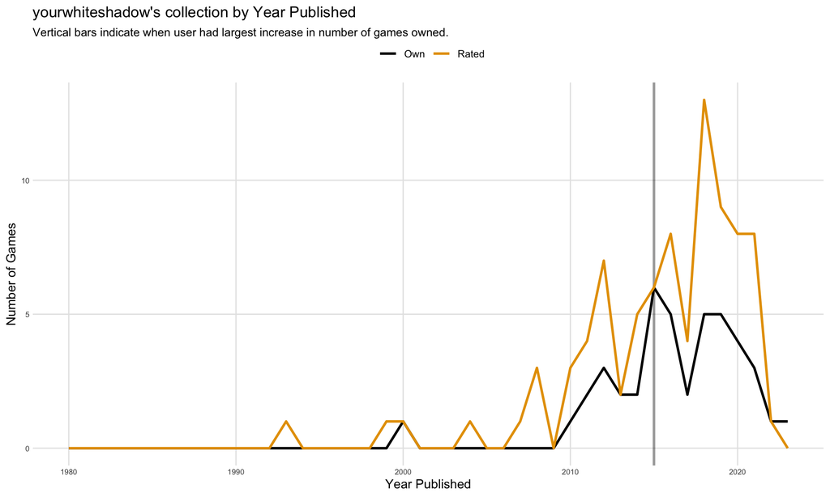

## 1.1 What types of games does yourwhiteshadow own?

We can look at the most frequent types of categories, mechanics, designers, and artists that appear in a user’s collection.

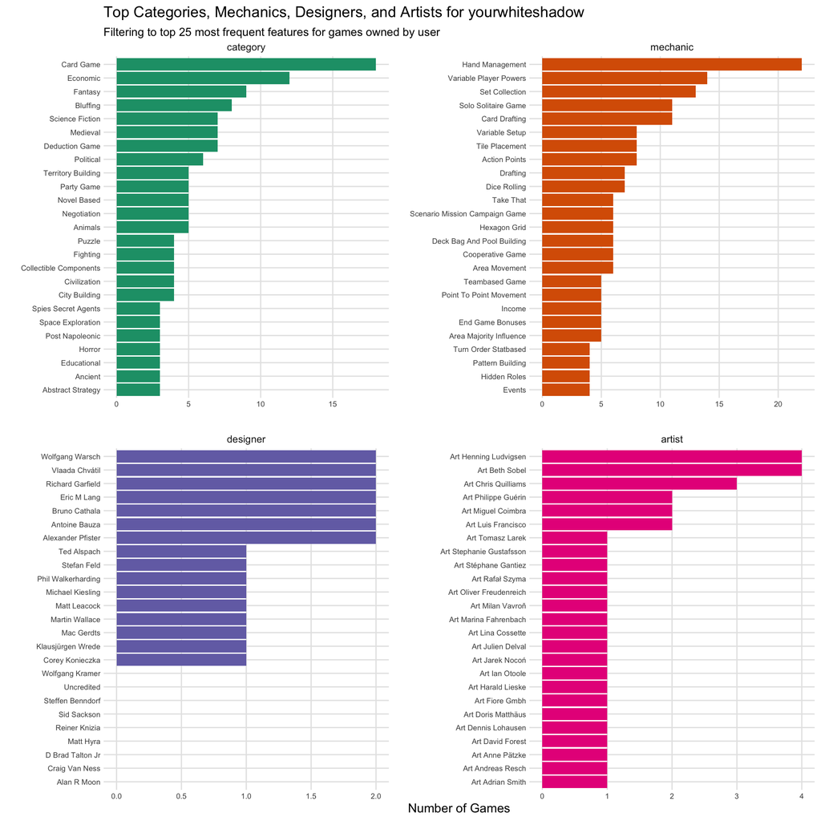

# 2 Modeling **yourwhiteshadow’s** Collection

| username | dataset | period | games_owned | games_rated | games_played |
| --- | --- | --- | --- | --- | --- |
| yourwhiteshadow | training | published before 2020 | 30 | 63 | 67 |
| yourwhiteshadow | test | published 2020 or later | 9 | 17 | 19 |

There are two main (binary) outcomes we will be modeling for the user.

The first, **own** refers to whether the user currently lists a game as owned in their collection. The second, **played** refers to whether the user currently owns, has rated, or previously owned a game. This means the latter will generally have a larger list of games, but may still be a useful category to examine for people who play lots of games without necessarily owning them.

We will train predictive models to learn the probability that the user will own or play individual games based on their features.

## 2.1 Coefficients for yourwhiteshadow

We can examine coefficients from the trained modes, which are penalized logistic regressions fit to our two main outcomes. Positive values indicate that a feature increases a user’s probabilility of owning/rating a game, while negative values indicate a feature decreases the probability.

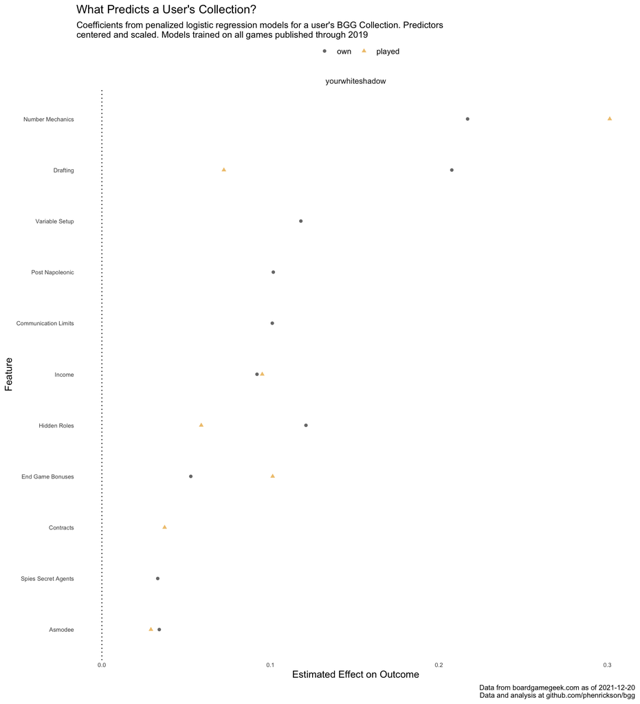

## 2.2 Visualizing Predictors for yourwhiteshadow’s Collection

Why did the model identify these features? We can make density plots of the important features for predicting whether the user owned a game. Blue indicates the density for games owned by the user, while grey indicates the density for games not owned by the user.

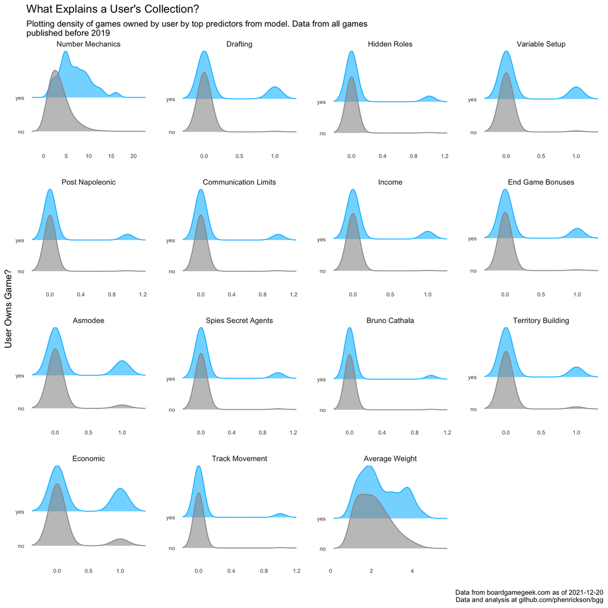

Binary predictors can be difficult to see with this visualization, so we can also directly examine the percentage of games in a user’s collection with a predictor vs the percentage of all games with that predictor.

| username | Feature | % of Games with Feature In_Collection | % of Games with Feature All_Games | Ratio |
| --- | --- | --- | --- | --- |
| yourwhiteshadow | Drafting | 20.0% | 1.0% | 20.3 |
| yourwhiteshadow | Income | 13.3% | 0.7% | 19.4 |
| yourwhiteshadow | Hidden Roles | 10.0% | 0.7% | 14.2 |
| yourwhiteshadow | End Game Bonuses | 16.7% | 1.2% | 13.4 |
| yourwhiteshadow | Post Napoleonic | 10.0% | 0.9% | 11.4 |
| yourwhiteshadow | Variable Setup | 20.0% | 1.8% | 10.9 |
| yourwhiteshadow | Communication Limits | 10.0% | 1.0% | 10.3 |
| yourwhiteshadow | Track Movement | 6.7% | 0.6% | 10.3 |
| yourwhiteshadow | Spies Secret Agents | 10.0% | 1.3% | 7.7 |
| yourwhiteshadow | Territory Building | 16.7% | 3.6% | 4.6 |
| yourwhiteshadow | Asmodee | 23.3% | 5.3% | 4.4 |
| yourwhiteshadow | Economic | 33.3% | 10.0% | 3.3 |
| yourwhiteshadow | Medieval | 20.0% | 6.3% | 3.2 |
| yourwhiteshadow | City Building | 13.3% | 4.3% | 3.1 |
| yourwhiteshadow | Negotiation | 10.0% | 3.6% | 2.8 |
| yourwhiteshadow | Puzzle | 6.7% | 3.4% | 2.0 |
| yourwhiteshadow | Party Game | 16.7% | 8.5% | 2.0 |
| yourwhiteshadow | Word Game | 3.3% | 1.8% | 1.9 |
| yourwhiteshadow | Horror | 3.3% | 4.0% | 0.8 |
| yourwhiteshadow | Trivia | 0.0% | 1.8% | 0.0 |
| yourwhiteshadow | Racing | 0.0% | 2.8% | 0.0 |
| yourwhiteshadow | Action Dexterity | 0.0% | 4.8% | 0.0 |
| yourwhiteshadow | Mafia | 0.0% | 0.7% | 0.0 |
| yourwhiteshadow | Trains | 0.0% | 2.2% | 0.0 |
| yourwhiteshadow | Prehistoric | 0.0% | 1.0% | 0.0 |

# 3 Assess Model’s Performance on Training Set

Before predicting games in upcoming years, we can examine how well the model did and what games it liked in the training set. In this case, we used resampling techniques (cross validation) to ensure that the model had not seen a game before making its predictions.

## 3.1 Separation Plot

An easy way to examine the performance of classification model is to view a separation plot. We plot the predicted probabilities from the model for every game (from resampling) from lowest to highest. We then overlay a blue line for any game that the user does own. A good classifier is one that is able to *separate* the blue (games owned by the user) from the white (games not owned by the user), with most of the blue occurring at the highest probabilities (right side of the chart).

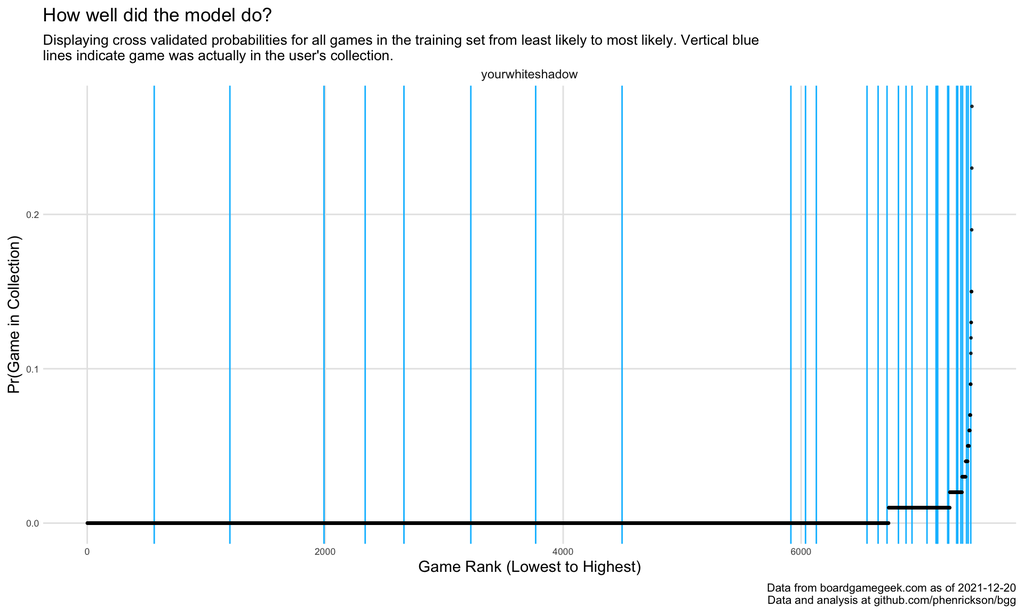

## 3.2 Top Games for **yourwhiteshadow** from Training Set

We can display this information in table form, displaying the 100 games with the highest probability of ownership, adding a blue line when the user does own the game.

| username | yearpublished | game_id | name | pred_played | pred_own | actual_played | actual_own |
| --- | --- | --- | --- | --- | --- | --- | --- |
| yourwhiteshadow | 2018 | 244711 | Newton | 0.20 | 0.27 | 0 | 0 |
| yourwhiteshadow | 2019 | 283863 | The Magnificent | 0.16 | 0.23 | 0 | 0 |
| yourwhiteshadow | 2014 | 156129 | Deception: Murder in Hong Kong | 0.01 | 0.19 | 0 | 0 |
| yourwhiteshadow | 2015 | 181687 | The Pursuit of Happiness | 0.15 | 0.15 | 0 | 0 |
| yourwhiteshadow | 2008 | 37111 | Battlestar Galactica: The Board Game | 0.11 | 0.15 | 0 | 0 |
| yourwhiteshadow | 2018 | 205896 | Rising Sun | 0.21 | 0.15 | 0 | 0 |
| yourwhiteshadow | 2019 | 281259 | The Isle of Cats | 0.08 | 0.13 | 0 | 0 |
| yourwhiteshadow | 2014 | 146886 | La Granja | 0.15 | 0.13 | 0 | 0 |
| yourwhiteshadow | 2007 | 29937 | König von Siam | 0.03 | 0.12 | 0 | 0 |
| yourwhiteshadow | 2014 | 163412 | Patchwork | 0.05 | 0.11 | 1 | 0 |
| yourwhiteshadow | 2019 | 260710 | Amul | 0.07 | 0.09 | 0 | 0 |
| yourwhiteshadow | 2012 | 120677 | Terra Mystica | 0.20 | 0.09 | 0 | 0 |
| yourwhiteshadow | 2016 | 167791 | Terraforming Mars | 0.25 | 0.09 | 1 | 1 |
| yourwhiteshadow | 2014 | 157354 | Five Tribes | 0.09 | 0.07 | 0 | 0 |
| yourwhiteshadow | 2019 | 261342 | Old West Empresario | 0.03 | 0.07 | 0 | 0 |
| yourwhiteshadow | 2000 | 478 | Citadels | 0.03 | 0.07 | 0 | 0 |
| yourwhiteshadow | 2016 | 192291 | Sushi Go Party! | 0.04 | 0.07 | 0 | 0 |
| yourwhiteshadow | 2013 | 133473 | Sushi Go! | 0.03 | 0.07 | 0 | 0 |
| yourwhiteshadow | 2016 | 155821 | Inis | 0.04 | 0.06 | 0 | 0 |
| yourwhiteshadow | 2017 | 184921 | Bunny Kingdom | 0.02 | 0.06 | 0 | 0 |
| yourwhiteshadow | 2019 | 249746 | Nanty Narking | 0.01 | 0.06 | 1 | 0 |
| yourwhiteshadow | 2017 | 220308 | Gaia Project | 0.07 | 0.06 | 0 | 0 |
| yourwhiteshadow | 2016 | 185589 | Islebound | 0.06 | 0.06 | 0 | 0 |
| yourwhiteshadow | 2013 | 141517 | A Study in Emerald | 0.05 | 0.06 | 0 | 0 |
| yourwhiteshadow | 2019 | 271324 | It's a Wonderful World | 0.05 | 0.06 | 1 | 0 |
| yourwhiteshadow | 2017 | 224037 | Codenames: Duet | 0.01 | 0.05 | 0 | 0 |
| yourwhiteshadow | 2017 | 228341 | Pulsar 2849 | 0.01 | 0.05 | 0 | 0 |
| yourwhiteshadow | 2019 | 283294 | Yukon Airways | 0.04 | 0.05 | 0 | 0 |
| yourwhiteshadow | 2011 | 70919 | Takenoko | 0.04 | 0.05 | 0 | 0 |
| yourwhiteshadow | 2018 | 224517 | Brass: Birmingham | 0.03 | 0.05 | 1 | 1 |

[output cut: 70 more lines]

We can also more formally assess how well the model did in resampling by looking at the area under the receiver operating characteristic. A perfect model would receive a score of 1, while a model that cannot predict the outcome will default to a score of 0.5. The extent to which something is a *good* score depends on the setting, but generally anything in the .8 to .9 range is very good while the .7 to .8 range is perfectly acceptable.

| username | outcome_type | .metric | .estimator | .estimate |
| --- | --- | --- | --- | --- |
| yourwhiteshadow | own | roc_auc | binary | 0.832 |
| yourwhiteshadow | played | roc_auc | binary | 0.816 |

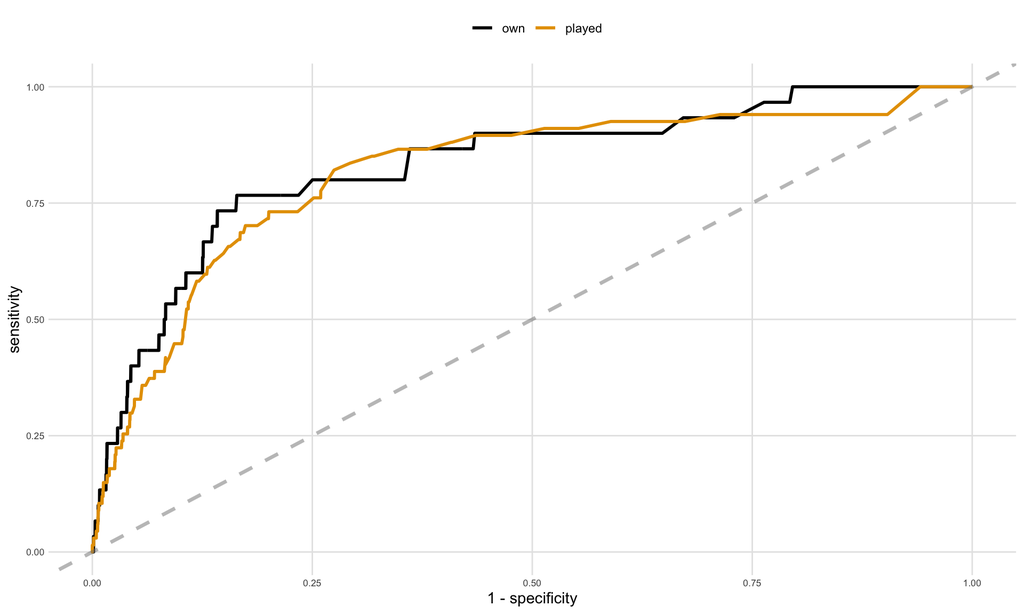

Another way to think about the model performance is to view its lift, or its ability to detect the positive outcomes over that of a null model. High lift indicates the model can much more quickly find all of the positive outcomes (in this case, games owned or played by the user), while a model with no lift is no better than random guessing.

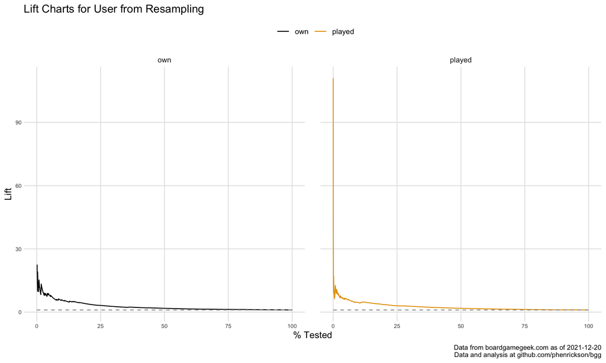

## 3.3 Most and Least Likely Games

What games does the model think yourwhiteshadow is **most likely to own** that are **not** in their collection?

| username | yearpublished | game_id | name | pred_own | actual_own |
| --- | --- | --- | --- | --- | --- |
| yourwhiteshadow | 2018 | 244711 | Newton | 0.27 | 0 |
| yourwhiteshadow | 2019 | 283863 | The Magnificent | 0.23 | 0 |
| yourwhiteshadow | 2014 | 156129 | Deception: Murder in Hong Kong | 0.19 | 0 |
| yourwhiteshadow | 2015 | 181687 | The Pursuit of Happiness | 0.15 | 0 |
| yourwhiteshadow | 2008 | 37111 | Battlestar Galactica: The Board Game | 0.15 | 0 |

What games does the model think yourwhiteshadow is **least likely to own** that **are** in their collection?

| username | yearpublished | game_id | name | pred_own | actual_own |
| --- | --- | --- | --- | --- | --- |
| yourwhiteshadow | 2015 | 173346 | 7 Wonders Duel | 0 | 1 |
| yourwhiteshadow | 2011 | 84876 | The Castles of Burgundy | 0 | 1 |
| yourwhiteshadow | 2016 | 193738 | Great Western Trail | 0 | 1 |
| yourwhiteshadow | 2018 | 244521 | The Quacks of Quedlinburg | 0 | 1 |
| yourwhiteshadow | 2015 | 140934 | Arboretum | 0 | 1 |

## 3.4 Top Games by Year

Top 25 games most likely to be owned by the user in each year, highlighting in blue the games that the user has owned/played.

| rank | 2011 | 2012 | 2013 | 2014 | 2015 | 2016 | 2017 | 2018 | 2019 |
| --- | --- | --- | --- | --- | --- | --- | --- | --- | --- |
| 1 | Takenoko | Terra Mystica | Sushi Go! | Deception: Murder in Hong Kong | The Pursuit of Happiness | Terraforming Mars | Bunny Kingdom | Newton | The Magnificent |
| 2 | Octopus's Garden | Keyflower | A Study in Emerald | La Granja | The Bloody Inn | Sushi Go Party! | Gaia Project | Rising Sun | The Isle of Cats |
| 3 | Tragedy Looper | Among the Stars | Castle Dice | Patchwork | One Night Revolution | Inis | Codenames: Duet | Brass: Birmingham | Amul |
| 4 | Mundus Novus | War of the Ring: Second Edition | Navajo Wars | Five Tribes | Blood Rage | Islebound | Pulsar 2849 | Sprawlopolis | Old West Empresario |
| 5 | A Few Acres of Snow | Wiz-War (Eighth Edition) | Mascarade | Praetor | Grand Austria Hotel | Codenames: Pictures | Pendragon: The Fall of Roman Britain | Decrypto | Nanty Narking |
| 6 | Sekigahara: The Unification of Japan | Seasons | Le Fantôme de l'Opéra | Imperial Settlers | A Study in Emerald (Second Edition) | The Networks | Gloomhaven | Architects of the West Kingdom | It's a Wonderful World |
| 7 | 1955: The War of Espionage | Kairo | Longhorn | Castles of Mad King Ludwig | I, Spy | Agricola (Revised Edition) | Paper Tales | Nemesis | Yukon Airways |
| 8 | Ora et Labora | Smash Up | Colonialism | Legendary Encounters: An Alien Deck Building Game | My Village | New Angeles | Harvest Dice | Kero | Minecraft: Builders & Biomes |
| 9 | Space Empires: 4X | Pax Porfiriana | The Witches: A Discworld Game | Fields of Arle | Runebound (Third Edition) | Capital Lux | LYNGK | Dice Hospital | Aquatica |
| 10 | Discworld: Ankh-Morpork | The Manhattan Project | Eight-Minute Empire: Legends | Sons of Anarchy: Men of Mayhem | The Foreign King | Timebomb | Photosynthesis | That's Pretty Clever! | Maracaibo |
| 11 | Kingdom Builder | Antike Duellum | Legacy: The Testament of Duke de Crecy | Sheep & Thief | 504 | Roll Player | Sagrada | Cahoots | De Vulgari Eloquentia: Deluxe Edition |
| 12 | Rory's Story Cubes: Voyages | Targi | Prosperity | [redacted] | Best Treehouse Ever | Yokohama | Pocket Mars | Key Flow | Paris: La Cité de la Lumière |
| 13 | Dark Moon | Polis: Fight for the Hegemony | Pocket Imperium | Spurs: A Tale in the Old West | New Salem | La Granja: No Siesta | Clans of Caledonia | Obsession | Freshwater Fly |
| 14 | Letters from Whitechapel | Suburbia | The Great Heartland Hauling Co. | Istanbul | Between Two Cities | Kingdomino | Codenames: Marvel | Everdell | Paris: New Eden |
| 15 | Dungeon Fighter | Tzolk'in: The Mayan Calendar | Archon: Glory & Machination | The Walled City: Londonderry & Borderlands | Nevermore | Junk Art | Calimala | Underwater Cities | Yōkai |
| 16 | A Game of Thrones: The Board Game (Second Edition) | Divided Republic | BANG! The Dice Game | Abyss | One Night Ultimate Vampire | Secret Hitler | Dungeon Draft | Street Masters | Barrage |
| 17 | Dr. Shark | Il Vecchio | Concept | DungeonQuest Revised Edition | RYŪ | When I Dream | Aristeia! | Forum Trajanum | Trismegistus: The Ultimate Formula |
| 18 | King of Tokyo | Clash of Cultures | Rory's Story Cubes: Enchanted | Arkwright | The Grizzled | 13 Days: The Cuban Missile Crisis | Smash Up: What Were We Thinking? | Human Punishment: Social Deduction 2.0 | Chai |
| 19 | Warriors & Traders | Merchant of Venus (Second Edition) | Rory's Story Cubes: Prehistoria | Madame Ching | FUSE | Exceed Fighting System | Tesla vs. Edison: Duel | Werewords Deluxe Edition | The Taverns of Tiefenthal |
| 20 | Strasbourg | Freedom: The Underground Railroad | Caverna: The Cave Farmers | Red7 | The U.S. Civil War | Covert | Fog of Love | A Song of Ice & Fire: Tabletop Miniatures Game – Stark vs Lannister Starter Set | Era: Medieval Age |
| 21 | Band of Brothers: Screaming Eagles | Secret Code 13+4 | Two Rooms and a Boom | Mythotopia | ...and then, we held hands. | First Class: All Aboard the Orient Express! | Fugitive | Duelosaur Island | Last Bastion |
| 22 | Fighting Formations: Grossdeutschland Motorized Infantry Division | VivaJava: The Coffee Game | Race! Formula 90 | Clinic | Raptor | Hit Z Road | Tortuga 1667 | At Any Cost: Metz 1870 | Herbaceous Sprouts |
| 23 | No Retreat! The Russian Front | Kill the Overlord | Gear & Piston | Alchemists | Coffee Roaster | Tyrants of the Underdark | Fallout | Jurassic Snack | Dizzle |
| 24 | Nightfighter | One Night Werewolf | Impulse | Desperados of Dice Town | Rolling America | Aeon's End | Rajas of the Ganges | Lords of Hellas | Twice as Clever! |
| 25 | Space Infantry | Exodus: Proxima Centauri | Friese's Landlord | Melee | Haspelknecht | Clank!: A Deck-Building Adventure | The Palace of Mad King Ludwig | Root | Noctiluca |

## 3.5 Interactive Predictions from Resampling

Interactive table for predictions from resampling.

|  | username | yearpublished | rank | game_id | name | pred_played | pred_own | actual_played | actual_own |
| --- | --- | --- | --- | --- | --- | --- | --- | --- | --- |
| 1 | yourwhiteshadow | 1900 | 223 | 2397 | Backgammon | 0.01 | 0.01 | 0 | 0 |
| 2 | yourwhiteshadow | 1900 | 581 | 2785 | Game of Goose | 0.01 | 0.01 | 0 | 0 |
| 3 | yourwhiteshadow | 1900 | 716 | 5546 | Marbles | 0.01 | 0 | 0 | 0 |
| 4 | yourwhiteshadow | 1900 | 719 | 11901 | Tic-Tac-Toe | 0.01 | 0 | 0 | 0 |
| 5 | yourwhiteshadow | 1900 | 766 | 188 | Go | 0.01 | 0 | 0 | 0 |
| 6 | yourwhiteshadow | 1900 | 866 | 171 | Chess | 0.01 | 0 | 0 | 0 |
| 7 | yourwhiteshadow | 1900 | 874 | 2065 | Shogi | 0.01 | 0 | 0 | 0 |
| 8 | yourwhiteshadow | 1900 | 876 | 2393 | Xiangqi | 0.01 | 0 | 0 | 0 |
| 9 | yourwhiteshadow | 1900 | 1101 | 26952 | International Checkers | 0.01 | 0 | 0 | 0 |
| 10 | yourwhiteshadow | 1900 | 1138 | 1602 | The Royal Game of Ur | 0.01 | 0 | 0 | 0 |

[output cut: 7426 more lines]

# 4 Validating the Model on 2020

How well did a model trained on a user’s collection through 2019 perform in predicting games for the user from 2020?

| username | outcome_type | yearpublished | .metric | .estimator | .estimate |
| --- | --- | --- | --- | --- | --- |
| yourwhiteshadow | own | 2020 | roc_auc | binary | 0.744 |
| yourwhiteshadow | played | 2020 | roc_auc | binary | 0.767 |

Table of top 25 games from 2020, highlighting games that the user owns.

| username | yearpublished | game_id | name | pred_own | pred_played | actual_own | actual_played |
| --- | --- | --- | --- | --- | --- | --- | --- |
| yourwhiteshadow | 2020 | 184267 | On Mars | 0.27 | 0.45 | 0 | 0 |
| yourwhiteshadow | 2020 | 297030 | Tekhenu: Obelisk of the Sun | 0.16 | 0.06 | 0 | 0 |
| yourwhiteshadow | 2020 | 292333 | Cowboys II: Cowboys & Indians Edition | 0.10 | 0.10 | 0 | 0 |
| yourwhiteshadow | 2020 | 297204 | Traintopia | 0.09 | 0.05 | 0 | 0 |
| yourwhiteshadow | 2020 | 300322 | Hallertau | 0.08 | 0.18 | 0 | 0 |
| yourwhiteshadow | 2020 | 308765 | Praga Caput Regni | 0.06 | 0.11 | 0 | 0 |
| yourwhiteshadow | 2020 | 256317 | Guild Master | 0.05 | 0.24 | 0 | 0 |
| yourwhiteshadow | 2020 | 302465 | Obsidia | 0.05 | 0.05 | 0 | 0 |
| yourwhiteshadow | 2020 | 299960 | Alma Mater | 0.04 | 0.04 | 0 | 0 |
| yourwhiteshadow | 2020 | 307844 | Atheneum: Mystic Library | 0.04 | 0.06 | 0 | 0 |
| yourwhiteshadow | 2020 | 323784 | Ghost Letters | 0.04 | 0.02 | 0 | 0 |
| yourwhiteshadow | 2020 | 245224 | La Belle Époque | 0.03 | 0.01 | 0 | 0 |
| yourwhiteshadow | 2020 | 271002 | Myraclia | 0.03 | 0.02 | 0 | 0 |
| yourwhiteshadow | 2020 | 291457 | Gloomhaven: Jaws of the Lion | 0.03 | 0.05 | 0 | 0 |
| yourwhiteshadow | 2020 | 316377 | 7 Wonders (Second Edition) | 0.03 | 0.02 | 0 | 0 |
| yourwhiteshadow | 2020 | 317231 | Monasterium | 0.03 | 0.02 | 0 | 0 |
| yourwhiteshadow | 2020 | 319966 | The King Is Dead: Second Edition | 0.03 | 0.01 | 0 | 0 |
| yourwhiteshadow | 2020 | 246900 | Eclipse: Second Dawn for the Galaxy | 0.02 | 0.08 | 0 | 0 |
| yourwhiteshadow | 2020 | 263421 | Enigma: Beyond Code | 0.02 | 0.02 | 0 | 0 |
| yourwhiteshadow | 2020 | 267009 | Rome & Roll | 0.02 | 0.02 | 0 | 0 |
| yourwhiteshadow | 2020 | 270143 | Kōhaku | 0.02 | 0.01 | 0 | 0 |
| yourwhiteshadow | 2020 | 277927 | Bites | 0.02 | 0.03 | 0 | 0 |
| yourwhiteshadow | 2020 | 292487 | 10 Gallon Tank | 0.02 | 0.01 | 0 | 0 |
| yourwhiteshadow | 2020 | 292971 | Ettin | 0.02 | 0.01 | 0 | 0 |
| yourwhiteshadow | 2020 | 294788 | Conqueror: Final Conquest | 0.02 | 0.06 | 0 | 0 |

# 5 Predicting Upcoming Games (2020 and On) for **yourwhiteshadow**

Examine the top games for the test set.

| username | yearpublished | game_id | name | rank | own | played |
| --- | --- | --- | --- | --- | --- | --- |
| yourwhiteshadow | 2020 | 184267 | On Mars | 1 | 0.27 | 0.45 |
| yourwhiteshadow | 2020 | 297030 | Tekhenu: Obelisk of the Sun | 2 | 0.16 | 0.06 |
| yourwhiteshadow | 2020 | 292333 | Cowboys II: Cowboys & Indians Edition | 3 | 0.10 | 0.10 |
| yourwhiteshadow | 2020 | 297204 | Traintopia | 4 | 0.09 | 0.05 |
| yourwhiteshadow | 2020 | 300322 | Hallertau | 5 | 0.08 | 0.18 |
| yourwhiteshadow | 2020 | 308765 | Praga Caput Regni | 6 | 0.06 | 0.11 |
| yourwhiteshadow | 2020 | 256317 | Guild Master | 7 | 0.05 | 0.24 |
| yourwhiteshadow | 2020 | 302465 | Obsidia | 8 | 0.05 | 0.05 |
| yourwhiteshadow | 2020 | 323784 | Ghost Letters | 9 | 0.04 | 0.02 |
| yourwhiteshadow | 2020 | 299960 | Alma Mater | 10 | 0.04 | 0.04 |
| yourwhiteshadow | 2020 | 307844 | Atheneum: Mystic Library | 11 | 0.04 | 0.06 |
| yourwhiteshadow | 2020 | 317231 | Monasterium | 12 | 0.03 | 0.02 |
| yourwhiteshadow | 2020 | 319966 | The King Is Dead: Second Edition | 13 | 0.03 | 0.01 |
| yourwhiteshadow | 2020 | 245224 | La Belle Époque | 14 | 0.03 | 0.01 |
| yourwhiteshadow | 2020 | 291457 | Gloomhaven: Jaws of the Lion | 15 | 0.03 | 0.05 |
| yourwhiteshadow | 2020 | 271002 | Myraclia | 16 | 0.03 | 0.02 |
| yourwhiteshadow | 2020 | 316377 | 7 Wonders (Second Edition) | 17 | 0.03 | 0.02 |
| yourwhiteshadow | 2020 | 315954 | Hunt A Killer: Death at the Dive Bar | 18 | 0.02 | 0.02 |
| yourwhiteshadow | 2020 | 295905 | Cosmic Frog | 19 | 0.02 | 0.03 |
| yourwhiteshadow | 2020 | 299179 | Chancellorsville 1863 | 20 | 0.02 | 0.03 |
| yourwhiteshadow | 2020 | 294788 | Conqueror: Final Conquest | 21 | 0.02 | 0.06 |
| yourwhiteshadow | 2020 | 301009 | Piece of Pie | 22 | 0.02 | 0.01 |
| yourwhiteshadow | 2020 | 311829 | The Arctic | 23 | 0.02 | 0.01 |
| yourwhiteshadow | 2020 | 277927 | Bites | 24 | 0.02 | 0.03 |
| yourwhiteshadow | 2020 | 308652 | Age of Dogfights: WW1 | 25 | 0.02 | 0.03 |
| yourwhiteshadow | 2021 | 291847 | Mantis Falls | 1 | 0.28 | 0.07 |
| yourwhiteshadow | 2021 | 343905 | Boonlake | 2 | 0.09 | 0.23 |
| yourwhiteshadow | 2021 | 291859 | Riftforce | 3 | 0.08 | 0.03 |
| yourwhiteshadow | 2021 | 298102 | Roll Camera!: The Filmmaking Board Game | 4 | 0.07 | 0.07 |
| yourwhiteshadow | 2021 | 320992 | The Specialists | 5 | 0.06 | 0.03 |
| yourwhiteshadow | 2021 | 322588 | Origins: First Builders | 6 | 0.06 | 0.02 |
| yourwhiteshadow | 2021 | 342942 | Ark Nova | 7 | 0.06 | 0.12 |
| yourwhiteshadow | 2021 | 295947 | Cascadia | 8 | 0.06 | 0.02 |
| yourwhiteshadow | 2021 | 301018 | Dragon Parks | 9 | 0.06 | 0.02 |
| yourwhiteshadow | 2021 | 319999 | Dungeon Decorators | 10 | 0.05 | 0.09 |
| yourwhiteshadow | 2021 | 252752 | Genotype: A Mendelian Genetics Game | 11 | 0.04 | 0.04 |
| yourwhiteshadow | 2021 | 313269 | Rescuing Robin Hood | 12 | 0.04 | 0.03 |
| yourwhiteshadow | 2021 | 290618 | Wishland | 13 | 0.04 | 0.07 |
| yourwhiteshadow | 2021 | 295535 | Dark Ages: Heritage of Charlemagne | 14 | 0.04 | 0.05 |
| yourwhiteshadow | 2021 | 304985 | Dark Ages: Holy Roman Empire | 15 | 0.04 | 0.05 |
| yourwhiteshadow | 2021 | 310873 | Carnegie | 16 | 0.04 | 0.22 |
| yourwhiteshadow | 2021 | 340041 | Kingdomino Origins | 17 | 0.03 | 0.01 |
| yourwhiteshadow | 2021 | 316287 | Quest | 18 | 0.03 | 0.03 |
| yourwhiteshadow | 2021 | 298383 | Golem | 19 | 0.03 | 0.04 |
| yourwhiteshadow | 2021 | 314088 | Agropolis | 20 | 0.03 | 0.02 |
| yourwhiteshadow | 2021 | 318084 | Furnace | 21 | 0.03 | 0.01 |
| yourwhiteshadow | 2021 | 301441 | Drawn to Adventure | 22 | 0.03 | 0.02 |
| yourwhiteshadow | 2021 | 309250 | Empyrean Hero: The Card Game | 23 | 0.03 | 0.02 |
| yourwhiteshadow | 2021 | 333553 | For the King (and Me) | 24 | 0.03 | 0.02 |
| yourwhiteshadow | 2021 | 316786 | Tabannusi: Builders of Ur | 25 | 0.03 | 0.02 |
| yourwhiteshadow | 2022 | 334065 | Verdant | 1 | 0.08 | 0.03 |
| yourwhiteshadow | 2022 | 317511 | Tindaya | 2 | 0.03 | 0.09 |
| yourwhiteshadow | 2022 | 283137 | Human Punishment: The Beginning | 3 | 0.03 | 0.04 |
| yourwhiteshadow | 2022 | 320718 | Hidden Leaders | 4 | 0.02 | 0.02 |
| yourwhiteshadow | 2022 | 271601 | Feed the Kraken | 5 | 0.02 | 0.03 |
| yourwhiteshadow | 2022 | 319807 | Shogun no Katana | 6 | 0.02 | 0.04 |
| yourwhiteshadow | 2022 | 326945 | Castles of Mad King Ludwig: Collector's Edition | 7 | 0.02 | 0.03 |
| yourwhiteshadow | 2022 | 331106 | The Witcher: Old World | 8 | 0.02 | 0.04 |
| yourwhiteshadow | 2022 | 295770 | Frosthaven | 9 | 0.02 | 0.04 |
| yourwhiteshadow | 2022 | 336986 | Flamecraft | 10 | 0.01 | 0.03 |
| yourwhiteshadow | 2022 | 281258 | Sub Terra II: Inferno's Edge | 11 | 0.01 | 0.02 |
| yourwhiteshadow | 2022 | 311823 | Nova Aetas Renaissance | 12 | 0.01 | 0.02 |
| yourwhiteshadow | 2022 | 312959 | Rallyman: DIRT | 13 | 0.01 | 0.02 |
| yourwhiteshadow | 2022 | 295374 | Long Shot: The Dice Game | 14 | 0.01 | 0.03 |
| yourwhiteshadow | 2022 | 335427 | Wild: Serengeti | 15 | 0.01 | 0.03 |
| yourwhiteshadow | 2022 | 324090 | Scarface 1920 | 16 | 0.01 | 0.03 |
| yourwhiteshadow | 2022 | 273814 | Deliverance | 17 | 0.01 | 0.03 |
| yourwhiteshadow | 2022 | 317321 | Darkest Dungeon: The Board Game | 18 | 0.01 | 0.03 |
| yourwhiteshadow | 2022 | 305096 | Endless Winter: Paleoamericans | 19 | 0.01 | 0.03 |
| yourwhiteshadow | 2022 | 304051 | Creature Comforts | 20 | 0.01 | 0.06 |
| yourwhiteshadow | 2022 | 280726 | Legacies | 21 | 0.01 | 0.04 |
| yourwhiteshadow | 2022 | 322524 | Bardsung | 22 | 0.01 | 0.04 |
| yourwhiteshadow | 2022 | 322289 | Darwin's Journey | 23 | 0.01 | 0.02 |
| yourwhiteshadow | 2022 | 284189 | Foundations of Rome | 24 | 0.01 | 0.03 |
| yourwhiteshadow | 2022 | 295895 | Distilled | 25 | 0.01 | 0.03 |

## 5.1 Interactive Table for Upcoming Games 2020 and On

|  | username | yearpublished | game_id | name | rank | own | played |
| --- | --- | --- | --- | --- | --- | --- | --- |
| 1 | yourwhiteshadow | 2021 | 291847 | Mantis Falls | 1 | 0.28 | 0.07 |
| 2 | yourwhiteshadow | 2020 | 184267 | On Mars | 2 | 0.27 | 0.45 |
| 3 | yourwhiteshadow | 2020 | 297030 | Tekhenu: Obelisk of the Sun | 3 | 0.16 | 0.06 |
| 4 | yourwhiteshadow | 2020 | 292333 | Cowboys II: Cowboys &amp; Indians Edition | 4 | 0.1 | 0.1 |
| 5 | yourwhiteshadow | 2020 | 297204 | Traintopia | 5 | 0.09 | 0.05 |
| 6 | yourwhiteshadow | 2021 | 343905 | Boonlake | 6 | 0.09 | 0.23 |
| 7 | yourwhiteshadow | 2020 | 300322 | Hallertau | 7 | 0.08 | 0.18 |
| 8 | yourwhiteshadow | 2022 | 334065 | Verdant | 8 | 0.08 | 0.03 |
| 9 | yourwhiteshadow | 2021 | 291859 | Riftforce | 9 | 0.08 | 0.03 |
| 10 | yourwhiteshadow | 2021 | 298102 | Roll Camera!: The Filmmaking Board Game | 10 | 0.07 | 0.07 |

[output cut: 1627 more lines]